# Overlapping_genes_DESeq2

Author

Pakorn Sagulkoo

After we carried out psedobulk gene expression analysis and GSEA for several RT scRNA-seq datasets, we will evaluate the consistency of gene expression results across those studies with calculated from Pseudobulk analysis using DESeq2. We will explore overlapping genes among those studies.

# Import the relevant packages and set working path directory

```r
# Import the relavant packages
library(UpSetR)
library(dplyr)
library(tibble)
library(stringr)
library(ggplot2)
library(ggrepel)
```

```r
# Check root path
here::here()
```

```
[1] "/mnt/hp-storage/users/pakorns"
```

# Define paths

```r
# Define paths to load and save files
path_to_single_cell_analysis <- here::here("scRNAseq/systematic_review")
path_to_save_up_common_degs <- here::here("scRNAseq/systematic_review/6-consistency_assessment/overlapping_genes/deseq2/1.upregulated_common_degs.txt")
path_to_save_down_common_degs <- here::here("scRNAseq/systematic_review/6-consistency_assessment/overlapping_genes/deseq2/1.downregulated_common_degs.txt")
path_to_save_up_consist_rp <- here::here("scRNAseq/systematic_review/6-consistency_assessment/overlapping_genes/deseq2/2.upregulated_rp.rds")
path_to_save_down_consist_rp <- here::here("scRNAseq/systematic_review/6-consistency_assessment/overlapping_genes/deseq2/2.downregulated_rp.rds")
path_to_save_up_consist_rs <- here::here("scRNAseq/systematic_review/6-consistency_assessment/overlapping_genes/deseq2/2.upregulated_rs.rds")
path_to_save_down_consist_rs <- here::here("scRNAseq/systematic_review/6-consistency_assessment/overlapping_genes/deseq2/2.downregulated_rs.rds")
path_to_save_up_consist_degs <- here::here("scRNAseq/systematic_review/6-consistency_assessment/overlapping_genes/deseq2/3.upregulated_consist_degs.txt")
path_to_save_down_consist_degs <- here::here("scRNAseq/systematic_review/6-consistency_assessment/overlapping_genes/deseq2/3.downregulated_consist_degs.txt")
```

# Load data and functions

```r
# Source functions
source(here::here("bin/utils.R"))
```

```r
# List file names of all studies
study.lst <- c("1-Penter_2021_GSE165087", "2-Nadeu_2022", "3-Hing_2023_GSE205704", "4-Parry_2023b", "5-Rigo_2024")
study.lst
```

```
[1] "1-Penter_2021_GSE165087" "2-Nadeu_2022"
[3] "3-Hing_2023_GSE205704"   "4-Parry_2023b"
[5] "5-Rigo_2024"
```

```r
# Create names for list later
names.lst <- sub(
  "^\\d+-([A-Za-z]+)_([0-9]{4}[A-Za-z]?).*$",  # capture name and year
  "\\1(\\2)",                         # output as Name(Year)
  study.lst
)
names.lst
```

```
[1] "Penter(2021)" "Nadeu(2022)"  "Hing(2023)"   "Parry(2023b)" "Rigo(2024)"
```

```r
# Extract only name of studies
study_names <- sub("^\\d+-([^_0-9]+).*", "\\1", study.lst)
study_names
```

```
[1] "Penter" "Nadeu"  "Hing"   "Parry"  "Rigo"
```

# Pseudobulk gene expression using DESeq2

```r
# Load expression results in each study and collect in a list
path_to_download <- str_c(path_to_single_cell_analysis, "/", study.lst, "/pseudo_bulk_deseq2/", study_names, "_deseq2_dea.rds")
dea.lst <- purrr::pmap(
  list(path_to_download),
  function(path){
    expr.mat <- readRDS(path)
    return(expr.mat)
  }
)
names(dea.lst) <- names.lst
```

## Upregulated genes

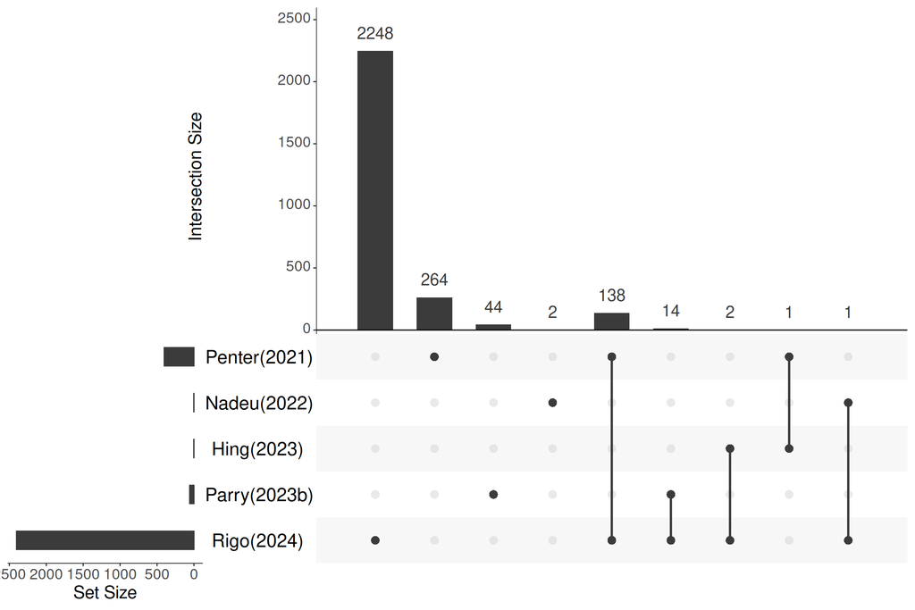

```r
# Extract adjusted significant upregulated genes
sig_upreg_gene.lst <- purrr::pmap(
  list(dea.lst),
  function(dea){
    dea <- dea[!is.na(dea$padj), ] # remove genes with padj = NA
    selected_gene <- rownames(dea[dea$log2FoldChange > 0.25 & dea$padj < 0.05,])
    return(selected_gene)
  }
)

# Reorder the list first
sig_upreg_gene.lst <- sig_upreg_gene.lst %>%
  purrr::discard(~ length(.x) == 0) %>%   # drop empty ones
  rev()                                   # reverse order

# Convert to UpSetR input
upset_data <- fromList(sig_upreg_gene.lst)

# Plot UpSetR
upset.plt <- upset(
  upset_data,
  sets = colnames(upset_data),
  keep.order = TRUE,
  nintersects = NA,
  point.size = 3.5,
  line.size = 1,
  text.scale = c(2, 2, 2, 2, 2.5, 2.5), # defined as c(intersection size title, intersection size tick labels, set size title, set size tick labels, set names, numbers above bars)
  mb.ratio = c(0.55, 0.45) # Adjust margin: give more space to the bottom/left for those large labels
)

upset.plt
```

We will collect the common upregulated DEGs from Penter and Rigo study.

```r
# Collect common upregulated DEGs found in two studies (Penter and Rigo)
two_common_up_degs <- Reduce(intersect, sig_upreg_gene.lst[names(sig_upreg_gene.lst) %in% c("Penter(2021)", "Rigo(2024)")])
two_common_up_degs
```

```
  [1] "ISG15"      "ACOT7"      "EIF3I"      "PSMB2"      "MRPS15"
  [6] "AKR1A1"     "GPX7"       "MRPL37"     "SERBP1"     "TYW3"
 [11] "GNG5"       "RTCA"       "PSMA5"      "NDUFS2"     "MGST3"
 [16] "MRPS14"     "SNRPE"      "AL445524.1" "COA6"       "ACP1"
 [21] "PPM1G"      "SUCLG1"     "IMP4"       "NMI"        "ATP5MC3"
 [26] "HSPD1"      "IMPDH2"     "PDHB"       "NIT2"       "NDUFB4"
 [31] "MGLL"       "ISY1"       "SERP1"      "NDUFB5"     "RTP4"
 [36] "CCDC50"     "HADH"       "MRPL36"     "TBCA"       "VDAC1"
 [41] "TXNDC15"    "RELL2"      "NPM1"       "RPL26L1"    "HNRNPAB"
 [46] "MRPS18B"    "HLA-DQA1"   "HMGA1"      "BYSL"       "MRPL14"
 [51] "SNX3"       "GGCT"       "NT5C3A"     "MRPS24"     "YWHAG"
 [56] "MRPS33"     "COPS5"      "FABP5"      "TATDN1"     "NDUFB9"
 [61] "NSMCE2"     "ZFAT"       "STOML2"     "CLTA"       "GRHPR"
 [66] "TXN"        "PSMB7"      "ATP5F1C"    "PPA1"       "MRPS16"
 [71] "VDAC2"      "PDLIM1"     "GSTO1"      "PRDX3"      "GLRX3"
 [76] "PSMA1"      "LDHA"       "EIF3M"      "TIMM10"     "C11orf1"
 [81] "FEZ1"       "NDUFA9"     "GAPDH"      "TPI1"       "LDHB"
 [86] "STAC3"      "C12orf73"   "GPN3"       "GTF2F2"     "ESD"
 [91] "CHAMP1"     "APEX1"      "PSMB5"      "PRORP"      "CNIH1"
 [96] "LGALS3"     "PSMA3"      "PCLAF"      "RAB11A"     "ETFA"
[101] "IDH2"       "MRPS34"     "MT2A"       "NOB1"       "HSBP1"
[106] "C1QBP"      "NME2"       "PTRH2"      "AFMID"      "ACAA2"
[111] "TXNL1"      "TIMM13"     "LRG1"       "CARM1"      "ACP5"
[116] "PDCD5"      "COX6B1"     "U2AF1L4"    "ZNF581"     "PFDN4"
[121] "FAM207A"    "BID"        "MIF"        "TTC28-AS1"  "HSCB"
[126] "UQCR10"     "TXN2"       "ADSL"       "ST13"       "RBX1"
[131] "SNU13"      "SAMM50"     "PARVB"      "PARVG"      "SCO2"
[136] "PDHA1"      "TCEAL8"     "SLC25A5"
```

## Downregulated genes

Since no downregulated DEGs were found in Nadeu study, we will remove it from the plot.

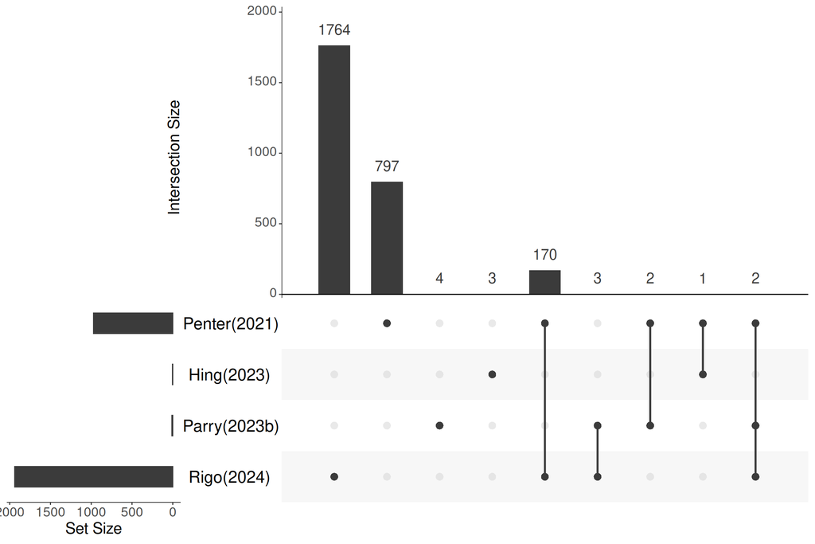

```r
# Extract adjusted significant downregulated genes
sig_downreg_gene.lst <- purrr::pmap(
  list(dea.lst),
  function(dea){
    dea <- dea[!is.na(dea$padj), ] # remove genes with padj = NA
    selected_gene <- rownames(dea[dea$log2FoldChange < (-0.25) & dea$padj < 0.05,])
    return(selected_gene)
  }
)

# Reorder the list first
sig_downreg_gene.lst <- sig_downreg_gene.lst %>%
  purrr::discard(~ length(.x) == 0) %>%   # drop empty ones
  rev()                                   # reverse order

# Convert to UpSetR input
upset_data <- fromList(sig_downreg_gene.lst)

# Plot UpSetR
upset.plt <- upset(
  upset_data,
  sets = colnames(upset_data),
  keep.order = TRUE,
  nintersects = NA,
  point.size = 3.5,
  line.size = 1,
  text.scale = c(2, 2, 2, 2, 2.5, 2.5), # defined as c(intersection size title, intersection size tick labels, set size title, set size tick labels, set names, numbers above bars)
  mb.ratio = c(0.55, 0.45) # Adjust margin: give more space to the bottom/left for those large labels
)

upset.plt
```

```r
# Collect common downregulated DEGs found in three studies (Penter, Parry, and Rigo)
three_common_down_degs <- Reduce(intersect,
                    sig_downreg_gene.lst[names(sig_downreg_gene.lst) %in% c("Penter(2021)", "Parry(2023b)", "Rigo(2024)")]
                    )
three_common_down_degs
```

```
[1] "SLC16A11" "FHL1"
```

```r
# Collect common downregulated DEGs found in two studies (Penter and Rigo)
two_common_down_degs <- Reduce(intersect, sig_downreg_gene.lst[names(sig_downreg_gene.lst) %in% c("Penter(2021)", "Rigo(2024)")])
two_common_down_degs
```

```
  [1] "AL691432.2"  "AL139246.5"  "RSRP1"       "MATN1-AS1"   "TLCD4"
  [6] "RGS2"        "MAP10"       "RHOB"        "GDF7"        "CCDC88A"
 [11] "TSGA10"      "ZC3H6"       "SFT2D3"      "MBD5"        "LINC01473"
 [16] "FGD5-AS1"    "EPM2AIP1"    "TASOR"       "H1FX"        "AC108718.1"
 [21] "RAP2B"       "CLNK"        "HS3ST1"      "AC006230.1"  "TAPT1"
 [26] "SEPSECS-AS1" "CLOCK"       "CEP135"      "AC124016.1"  "LEF1"
 [31] "AC097376.3"  "NR3C2"       "FAM218A"     "ANKH"        "PRKAA1"
 [36] "AC008875.3"  "SSBP2"       "ARRDC3"      "SMAD5"       "AL662844.4"
 [41] "PHF1"        "PNRC1"       "AKAP7"       "CAHM"        "ERV3-1"
 [46] "ABCB4"       "FAM3C"       "TCAF1"       "CNTNAP2"     "AC005229.4"
 [51] "FAM160B2"    "DUSP26"      "AC027702.1"  "KAT6A"       "AP3M2"
 [56] "HGSNAT"      "AC064807.1"  "RB1CC1"      "CHD7"        "SGK3"
 [61] "AC009812.1"  "KIAA2026"    "RANBP6"      "AL512625.3"  "TLE4"
 [66] "SECISBP2"    "FAM120AOS"   "ZNF169"      "LINC00476"   "ERCC6L2"
 [71] "CDC14B"      "TMEM38B"     "TTF1"        "SEC16A"      "LCN10"
```

[output cut: 20 more lines]

In comparison with the pseudobulk analysis performed using Seurat, no common DEGs were detected. Moreover, the numbers of both up- and downregulated DEGs in most studies (e.g. Nadeu, Hing and Parry) were very low. This is probably due to the small numbers of cells and low read counts, which result in low mean counts and, consequently, reduced statistical power in DESeq2. By contrast, two other studies yielded high numbers of individual and common DEGs (138 upregulated and 170 downregulated). In the Penter study, the inclusion of nine cases (27 samples) increased the statistical power to detect significant genes. In the Rigo study, pseudo-cases were created by artificially splitting a case into two, which may have reduced variance across samples and limited the number of outliers, thereby reducing the occurrence of NA values in the adjusted p-values.

```r
# Save the common DEG results
write.table(
  two_common_up_degs,
  file = path_to_save_up_common_degs,
  sep = "\t",
  quote = FALSE,
  row.names = FALSE,
  col.names = FALSE
)

write.table(
  two_common_down_degs,
  file = path_to_save_down_common_degs,
  sep = "\t",
  quote = FALSE,
  row.names = FALSE,
  col.names = FALSE
)
```

# Evaluate gene-ranked consistency

From the previous step, we got 138 and 170 for common up- and downregulated DEGs from two studies (Penter and Rigo). However, we are not sure if these DEGs are common from ranking by chance. We will evaluate thier rank based on log2FC by using RankProd package. The package evaluates the statistics of gene rank across several gene expression studies by modelling ranked genes as probability distribution for the sum of outcomes by rolling *K* dices with *N* faces, similar to measuring *N* genes in expression analysis across *K* replicates or studies.

```r
# Import the relavant packages
library(RankProd)
```

```r
# Join dea tables from all studies but not Rigo
common_dea.df <- dea.lst[[1]] %>%
  rownames_to_column("gene") %>%
  mutate(log2FC_1 = log2FoldChange) %>%
  select(gene, log2FC_1)

# Loop over the rest
for (i in 2:length(dea.lst)) {
  # Rename dynamically with :=
  df_i <- dea.lst[[i]] %>%
    rownames_to_column("gene") %>%
    mutate(!!paste0("log2FC_", i) := log2FoldChange) %>%
    select(gene, !!paste0("log2FC_", i))

  # Join onto the growing table
  common_dea.df <- full_join(common_dea.df, df_i, by = "gene")
}

# Result: one data frame with gene and log2FC_x columns
head(common_dea.df)
```

```
        gene   log2FC_1    log2FC_2   log2FC_3    log2FC_4   log2FC_5
1 AL627309.1 -0.1838900 -0.05313829  0.6904508          NA         NA
2 AL627309.5 -0.7943815 -0.12729473 -1.1854206  0.29473552  0.4026631
3  LINC01409 -2.4621895 -0.19060617 -1.2453835 -0.31003451  0.2706299
4  LINC01128 -0.3338573  0.36840065 -0.4314056  0.02870604 -0.2300078
5  LINC00115 -0.6797634 -0.42287351 -0.2119501 -0.12149529 -0.3006744
6     FAM41C -0.4085538 -0.28780388         NA -0.24821296  0.3231005
```

## Rank product

```r
# Perform Rank Product
expr_mat <- as.matrix(common_dea.df[ , -1])   # all columns except gene
rownames(expr_mat) <- common_dea.df$gene
cl=rep(1, ncol(expr_mat))
RP.out <- RankProducts(expr_mat, cl, na.rm=FALSE, logged=TRUE, rand=123)
```

```
Rank Product analysis for paired case


 done
```

```r
# Summarise results of significant consistent genes
RP_sig_results <- topGene(RP.out, cutoff=0.05, method="pfp", logged=TRUE, logbase=2, gene.names=rownames(expr_mat))
```

```
Table1: Genes called significant under class1 < class2

Table2: Genes called significant under class1 > class2
```

```r
# Upregulated genes table
RP_up_genes.df <- RP_sig_results[["Table2"]]
DT::datatable(RP_up_genes.df, options = list(scrollX = TRUE))
```

|  | gene.index | RP/Rsum | FC:(class1/class2) | pfp | P.value |
| --- | --- | --- | --- | --- | --- |
| SFRP2 | 19155 | 7 | 4.635 | 7.879e-11 | 3.948e-15 |
| LINC01605 | 17016 | 61 | 5.226 | 1.674e-05 | 1.677e-09 |
| PCLAF | 8374 | 126.8 | 3.246 | 0.0004978 | 7.483e-08 |
| CCR5AS | 12395 | 153.5 | 3.125 | 0.0009626 | 1.929e-07 |
| IGKV3OR2-268 | 15346 | 155.7 | 3.415 | 0.000828 | 2.075e-07 |
| AL513324.1 | 19955 | 166 | 3.267 | 0.0009429 | 2.835e-07 |
| TYMS | 9941 | 171.3 | 2.416 | 0.0009427 | 3.307e-07 |
| PRTN3 | 17044 | 178 | 3.708 | 0.0009933 | 3.982e-07 |
| CDCA7 | 12349 | 183 | 2.876 | 0.001009 | 4.551e-07 |
| FCER1G | 911 | 201.1 | 3.128 | 0.001432 | 7.178e-07 |

[output cut: 262 more lines]

```r
# Downregulated genes table
RP_down_genes.df <- RP_sig_results[["Table1"]]
DT::datatable(RP_down_genes.df, options = list(scrollX = TRUE))
```

|  | gene.index | RP/Rsum | FC:(class1/class2) | pfp | P.value |
| --- | --- | --- | --- | --- | --- |
| PHACTR2-AS1 | 18091 | 49 | 0.3198 | 1.02e-05 | 5.111e-10 |
| AP003900.1 | 18525 | 88 | 0.376 | 0.0001158 | 1.161e-08 |
| TAB3-AS2 | 18419 | 91 | 0.3786 | 9.184e-05 | 1.381e-08 |
| TMEM212-AS1 | 18030 | 117 | 0.3965 | 0.0002488 | 4.987e-08 |
| WIF1 | 19947 | 159 | 0.3393 | 0.0009164 | 2.296e-07 |
| AC008750.2 | 18376 | 176 | 0.4253 | 0.001254 | 3.769e-07 |
| AC018754.1 | 15185 | 180.9 | 0.294 | 0.001228 | 4.306e-07 |
| AC044849.1 | 4944 | 196.3 | 0.4097 | 0.001593 | 6.384e-07 |
| ARRDC3 | 3322 | 196.6 | 0.3305 | 0.001427 | 6.436e-07 |
| LINC00472 | 19157 | 244.3 | 0.3313 | 0.003602 | 1.805e-06 |

[output cut: 83 more lines]

We will overlapping rank-consistent genes between results from Seurat and DESeq2.

```r
# Define path for seurat results
path_to_seurat_up_consist_rp <- here::here("scRNAseq/systematic_review/6-consistency_assessment/overlapping_genes/seurat/2.upregulated_rp.rds")
path_to_seurat_down_consist_rp <- here::here("scRNAseq/systematic_review/6-consistency_assessment/overlapping_genes/seurat/2.downregulated_rp.rds")

# Import the data
seurat_upregulated_rp_result <- readRDS(path_to_seurat_up_consist_rp)
seurat_downregulated_rp_result <- readRDS(path_to_seurat_down_consist_rp)
```

```r
# Szymkiewicz–Simpson index between Seurat and DESeq2 upregulated rank-consistent genes
n_intersect <- length(intersect(rownames(RP_up_genes.df), rownames(seurat_upregulated_rp_result)))
total_n <- min(nrow(RP_up_genes.df), nrow(seurat_upregulated_rp_result)) # the number for seurat < deseq2
ss_idx <- n_intersect/total_n
ss_idx
```

```
[1] 0.7647059
```

```r
# Szymkiewicz–Simpson index between Seurat and DESeq2 downregulated rank-consistent genes
n_intersect <- length(intersect(rownames(RP_down_genes.df), rownames(seurat_downregulated_rp_result)))
total_n <- min(nrow(RP_down_genes.df), nrow(seurat_downregulated_rp_result)) # the number for seurat < deseq2
ss_idx <- n_intersect/total_n
ss_idx
```

```
[1] 0.5913978
```

We observed from the Szymkiewicz–Simpson indices for both up- and downregulated rank-consistent genes, the results obtained from Seurat and DESeq2 were comparable. This indicates that both methods are suitable for pseudobulk analysis, with DESeq2 providing a stricter statistical comparison of gene expression.

```r
# Save the RP results
saveRDS(RP_up_genes.df, path_to_save_up_consist_rp)
saveRDS(RP_down_genes.df, path_to_save_down_consist_rp)
```

## Rank sum

```r
# Perform Rank Sum
RS.out <- RankProducts(expr_mat, cl, na.rm=FALSE, calculateProduct=FALSE, logged=TRUE, rand=123)
```

```
Rank Product analysis for paired case


 done
```

```r
# Summarise results of significant consistent genes
RS_sig_results <- topGene(RS.out, cutoff=0.05, method="pfp", logged=TRUE, logbase=2, gene.names=rownames(expr_mat))
```

```
Table1: Genes called significant under class1 < class2

Table2: Genes called significant under class1 > class2
```

We will explore the RP results for both upregulated and downregulated genes.

```r
# Upregulated genes table
RS_up_genes.df <- RS_sig_results[["Table2"]]
DT::datatable(RS_up_genes.df, options = list(scrollX = TRUE))
```

|  | gene.index | RP/Rsum | FC:(class1/class2) | pfp | P.value |
| --- | --- | --- | --- | --- | --- |
| SFRP2 | 19155 | 7 | 4.635 | 2.046e-12 | 1.025e-16 |
| LINC01605 | 17016 | 61 | 5.226 | 6.708e-08 | 6.723e-12 |
| AL513324.1 | 19955 | 166 | 3.267 | 6.815e-06 | 1.024e-09 |
| PRTN3 | 17044 | 178 | 3.708 | 7.252e-06 | 1.453e-09 |
| ELANE | 15768 | 239 | 3.429 | 2.539e-05 | 6.361e-09 |
| HMGA1 | 3891 | 254.8 | 2.459 | 2.916e-05 | 8.765e-09 |
| IGKV3OR2-268 | 15346 | 330.5 | 3.415 | 9.192e-05 | 3.224e-08 |
| TXN | 5503 | 369.2 | 2.393 | 0.00014 | 5.612e-08 |
| PCLAF | 8374 | 377.8 | 3.246 | 0.0001397 | 6.298e-08 |
| CDKN3 | 7910 | 415 | 2.264 | 0.0002011 | 1.008e-07 |

[output cut: 817 more lines]

```r
# Downregulated genes table
RS_down_genes.df <- RS_sig_results[["Table1"]]
DT::datatable(RS_down_genes.df, options = list(scrollX = TRUE))
```

|  | gene.index | RP/Rsum | FC:(class1/class2) | pfp | P.value |
| --- | --- | --- | --- | --- | --- |
| PHACTR2-AS1 | 18091 | 49 | 0.3198 | 4.451e-08 | 2.23e-12 |
| AP003900.1 | 18525 | 88 | 0.376 | 4.234e-07 | 4.243e-11 |
| TAB3-AS2 | 18419 | 91 | 0.3786 | 3.34e-07 | 5.021e-11 |
| TMEM212-AS1 | 18030 | 117 | 0.3965 | 8.845e-07 | 1.773e-10 |
| WIF1 | 19947 | 159 | 0.3393 | 3.295e-06 | 8.255e-10 |
| AC008750.2 | 18376 | 176 | 0.4253 | 4.568e-06 | 1.373e-09 |
| AC091132.1 | 18506 | 308 | 0.4732 | 6.458e-05 | 2.265e-08 |
| AC018754.1 | 15185 | 330 | 0.294 | 7.982e-05 | 3.2e-08 |
| AC016866.1 | 19950 | 356 | 0.42 | 0.0001037 | 4.677e-08 |
| AC000065.2 | 18103 | 392 | 0.4919 | 0.0001512 | 7.575e-08 |

[output cut: 333 more lines]

We will overlapping rank-consistent genes between results from Seurat and DESeq2.

```r
# Define path for seurat results
path_to_seurat_up_consist_rs <- here::here("scRNAseq/systematic_review/6-consistency_assessment/overlapping_genes/seurat/2.upregulated_rs.rds")
path_to_seurat_down_consist_rs <- here::here("scRNAseq/systematic_review/6-consistency_assessment/overlapping_genes/seurat/2.downregulated_rs.rds")

# Import the data
seurat_upregulated_rs_result <- readRDS(path_to_seurat_up_consist_rs)
seurat_downregulated_rs_result <- readRDS(path_to_seurat_down_consist_rs)
```

```r
# Szymkiewicz–Simpson index between Seurat and DESeq2 upregulated rank-consistent genes
n_intersect <- length(intersect(rownames(RS_up_genes.df), rownames(seurat_upregulated_rs_result)))
total_n <- min(nrow(RS_up_genes.df), nrow(seurat_upregulated_rs_result)) # the number for seurat < deseq2
ss_idx <- n_intersect/total_n
ss_idx
```

```
[1] 0.7158404
```

```r
# Szymkiewicz–Simpson index between Seurat and DESeq2 downregulated rank-consistent genes
n_intersect <- length(intersect(rownames(RS_down_genes.df), rownames(seurat_downregulated_rs_result)))
total_n <- min(nrow(RS_down_genes.df), nrow(seurat_downregulated_rs_result)) # the number for seurat < deseq2
ss_idx <- n_intersect/total_n
ss_idx
```

```
[1] 0.6209913
```

```r
# Save the RP results
saveRDS(RS_up_genes.df, path_to_save_up_consist_rs)
saveRDS(RS_down_genes.df, path_to_save_down_consist_rs)
```

# Find overlapping between common DEGs and significant consistent ranked genes

```r
# Collect consistent gene names from both up- and downregulated genes
consist_up_genes <- rownames(RP_sig_results[["Table2"]])
consist_down_genes <- rownames(RP_sig_results[["Table1"]])
```

After that, we will identify overlappping genes in both DEGs and consistent ranked genes.

```r
# Finding overlapping upregulated genes between DEGs and consistent ranking
consist_rank_up_degs <- intersect(two_common_up_degs, consist_up_genes)
consist_rank_up_degs
```

```
 [1] "ACOT7"   "GPX7"    "HSPD1"   "IMPDH2"  "MGLL"    "VDAC1"   "HMGA1"
 [8] "BYSL"    "MRPL14"  "GGCT"    "MRPS33"  "FABP5"   "ZFAT"    "CLTA"
[15] "GRHPR"   "TXN"     "PPA1"    "PRDX3"   "LDHA"    "C11orf1" "FEZ1"
[22] "GAPDH"   "LDHB"    "PSMB5"   "LGALS3"  "PCLAF"   "MT2A"    "NOB1"
[29] "NME2"    "AFMID"   "TIMM13"  "LRG1"    "PDCD5"   "BID"     "MIF"
[36] "ADSL"    "PARVB"
```

```r
# Finding overlapping downregulated genes between DEGs and consistent ranking
consist_rank_down_degs <- intersect(two_common_down_degs, consist_down_genes)
consist_rank_down_degs
```

```
 [1] "TLCD4"      "H1FX"       "CEP135"     "FAM218A"    "SSBP2"
 [6] "ARRDC3"     "LCN10"      "LARGE2"     "MALAT1"     "FAM66C"
[11] "IRS2"       "AL136419.3" "SLC30A4"    "ACSM3"      "SLC43A2"
[16] "SLC16A11"   "ZNF441"     "FHL1"
```

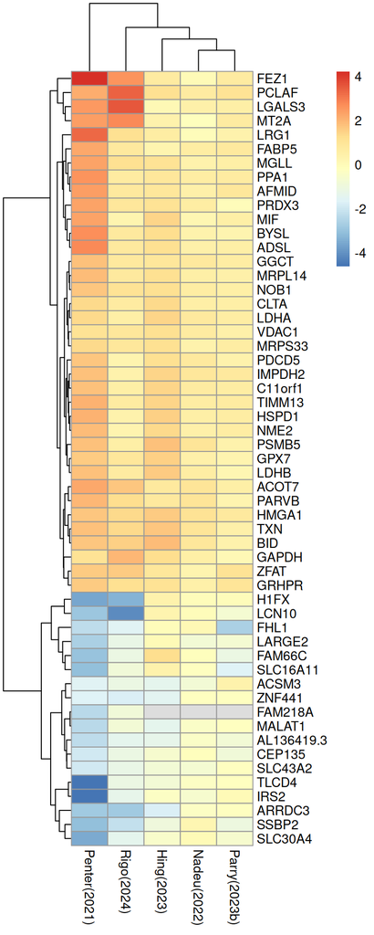

```r
# Visualise the heatmap
library(pheatmap)

# Extract expression matrix with rank-consistent DEGs
consiste_sig_genes <- c(consist_rank_up_degs, consist_rank_down_degs)
consiste_sig_expr_mat <- expr_mat[consiste_sig_genes, ]
colnames(consiste_sig_expr_mat) <- names.lst

# Plot the heatmap
pheatmap(consiste_sig_expr_mat, scale="none")
```

We will save these genes for further study and discussion.

```r
# Save the results
write.table(
  consist_rank_up_degs,
  file = path_to_save_up_consist_degs,
  sep = "\t",
  quote = FALSE,
  row.names = FALSE,
  col.names = FALSE
)

write.table(
  consist_rank_down_degs,
  file = path_to_save_down_consist_degs,
  sep = "\t",
  quote = FALSE,
  row.names = FALSE,
  col.names = FALSE
)
```